# SVMs for Toxic Comment Classification

Damon Pham, Samruda Pobbathi, Michael Zhou

Feb. 11, 2017

In this project, we use an SVM model to classify toxicity of online Wikipedia comments. (The results are later combined with another model to create an ensemble classifier.)

We began by lightly cleaning the data, removing any non-alphabetical or non-space character. In the future, stop words should also be removed.

```r
clean_text = function(text){
  text = str_replace_all(text, pattern='\n', replacement=' ')
  text = tolower(str_replace_all(text, '[^[A-Za-z ][:space:]]', replacement=' '))
  return(text)
}
```

```r
cwd = getwd()
setwd('..')
train = fread("data/train.csv")
setwd(cwd)
train$comment_text = clean_text(train$comment_text)
label.names = colnames(train)[3:8]
model.fnames = paste0('models/', label.names, '_svm_model.r')
doc_term_matrix.fnames = paste0('doc_term_matrices/', label.names, '_dtm.r')
container.fnames = paste0('containers/', label.names, '_container.r')
```

There are six classes of toxicity, and comments can belong to none, one, or multiple classes. Most comments do not fall under any class of toxicity.

We decided to build six models, one for each class, since they are not mutually exclusive.

For each model, we sampled 14000 observations from the entire training set. Within this sample, we selected 80% to train the model on, and 20% for out-of-sample evaluation. For both the test and train set, to ensure sufficient representation of the class of interest, we selected as many as possible and up to a half of the observations which belonged to that class. We then trained the model on the training subset.

```r
#Get the docterm.matrix and train the model.
for(i in 1:length(model.fnames)){
  model.fname = model.fnames[i]
  doc_term_matrix.fname = doc_term_matrix.fnames[i]
  container.fname = container.fnames[i]
  if(!file.exists(model.fname)){
    label.name = gsub('models/', '', gsub('_svm.*$', '', model.fname))
    print(paste0('sampling ', label.name))
    labels = train[[label.name]]

    SAMPLE.SIZE = 14000
    PROPORTION.TRAIN = 0.8
    ntrain = floor(SAMPLE.SIZE*PROPORTION.TRAIN)
    ntest = SAMPLE.SIZE - ntrain

    yes_label_indices = sample(which(labels==1))
    n_yes = length(yes_label_indices)
    n_yes.draw = ifelse(ceiling(SAMPLE.SIZE/2) < n_yes, ceiling(SAMPLE.SIZE/2), n_yes)
    n_yes.train = floor(n_yes.draw * PROPORTION.TRAIN)
    n_yes.test = floor(n_yes.draw * (1-PROPORTION.TRAIN))
    train_indices = yes_label_indices[1:n_yes.train]
    test_indices = yes_label_indices[(n_yes.train+1):(n_yes.train + n_yes.test)]

    no_label_indices = sample(which(labels==0))
    cutoff = ntrain - length(train_indices)
    train_indices = c(train_indices, no_label_indices[1:cutoff])
    no_label_indices = no_label_indices[(cutoff+1):length(no_label_indices)]
    cutoff = ntest - length(test_indices)
    test_indices = c(test_indices, no_label_indices[1:cutoff])

    model_subset = train[c(train_indices, test_indices)]
    labels=model_subset[[label.name]]
    print(paste0('making docterm matrix and container for ', label.name))
    docterm.matrix = create_matrix(model_subset$comment_text, removeSparseTerms=.999)
    container = create_container(docterm.matrix, labels=labels, trainSize = 1:ntrain,
                                 testSize = (ntrain+1):(ntrain+ntest), virgin=FALSE)

    print(paste0('training ', label.name))
    model = train_models(container, algorithms=c("SVM"), kernel="linear", cost=1)
    save(docterm.matrix, file=doc_term_matrix.fname)
    save(model, file=model.fname)
    save(container, file=container.fname)

  }
}
```

```r
#Error in source code: fix manually.
trace("create_matrix", edit=T) #'Acronym' -> 'acronym'
```

We then used the out-of-sample subset to evaluate each model’s performance. Here is the confusion matrix for each.

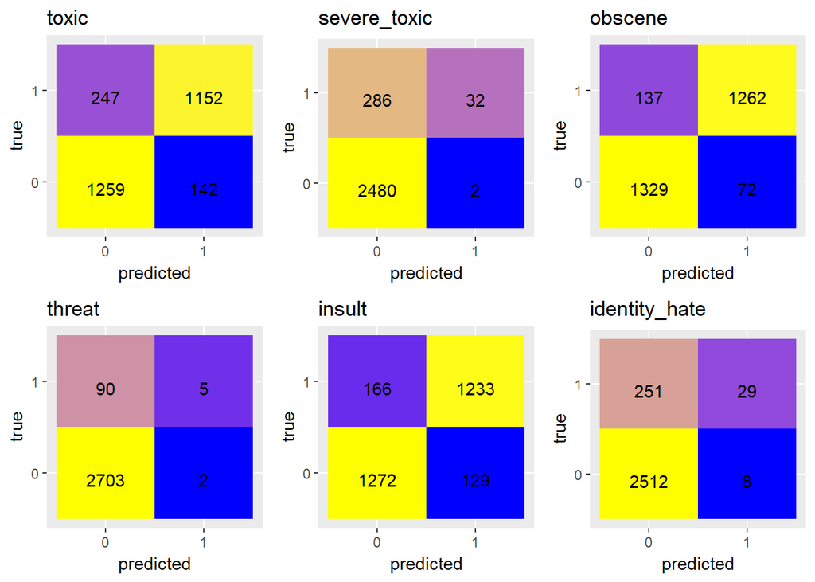

```r
p = vector(mode='list', length=length(model.fnames))
for(i in 1:length(model.fnames)){
  label.name = gsub('models/', '', gsub('_svm.*$', '', model.fnames[i]))
    load(model.fnames[i])
    load(container.fnames[i])

    true = container@testing_codes
    predicted = classify_model(container, model$SVM)$SVM_LABEL
    #print(confusionMatrix(data=predicted, reference=true, posi))

    confusion_matrix <- as.data.frame(table(predicted, true))

  p[[i]] = ggplot(data = confusion_matrix,
       mapping = aes(x = predicted,
                     y = true)) +
  geom_tile(aes(fill = Freq)) +
  geom_text(aes(label = sprintf("%1.0f", Freq)), vjust = 1) +
  scale_fill_gradient(low = "blue",
                      high = "yellow",
                      trans = "log") + theme(legend.position="none") +
                      labs(title=label.name)

  #analytics = create_analytics(container, classify_model(container, model$SVM))
  #print(kable(analytics@algorithm_summary, caption=paste0('Summary for ', label.name)))
}

grid.arrange(grobs=p, ncol=3)
```

```r
rm(list = setdiff(ls(), c('clean_text')))
```

We decided to go ahead and use this model to assign probabilities for each class for the real test dataset.

```r
labels = c("toxic","severe_toxic","obscene","threat","insult","identity_hate")
cwd = getwd()
setwd('..')
testdata = fread("data/test.csv")
setwd(cwd)
testdata$comment_text = clean_text(testdata$comment_text)
testdata.splitted = split(testdata, (seq(nrow(testdata))-1) %/% 2000)
rm(testdata)

for(i in 1:length(labels)){
  label=labels[i]
  load(paste0('models/', label, '_svm_model.r'))
  load(paste0('doc_term_matrices/', label, '_dtm.r'))

  chunk_probs = vector(mode='list', length=length(testdata.splitted))
  for(j in 1:length(testdata.splitted)){
    print(j)
    testdata.chunk = testdata.splitted[[j]]
    pred.matrix = create_matrix(testdata.chunk$comment_text, originalMatrix=docterm.matrix)
    predSize = nrow(testdata.chunk);
    predContainer = create_container(pred.matrix, rep(0,predSize), testSize=1:predSize, virgin=FALSE)
    results = classify_models(predContainer, model)
    chunk_probs[[j]] = ifelse(results$SVM_LABEL==1, results$SVM_PROB, 1-results$SVM_PROB)
  }
  final_result = data.frame(unlist(chunk_probs))
  colnames(final_result) = c('prob')
  write.table(final_result, file=paste0('preds/', labels[i], '_results.csv'), quote=FALSE, sep=',', row.names=FALSE)
}
```

```r
rm(chunk_probs, docterm.matrix, i, j, label, model, pred.matrix, predContainer, predSize, testdata.splitted)
probs = vector(mode='list', length=length(labels))
for(i in 1:length(labels)){
  label=labels[i]
  file = paste0('preds/', labels[i], '_results.csv')
  vec = fread(file)
  vec = round(vec, 4)
  colnames(vec) = c(label)
  probs[[i]]=vec
}

allprobs = as.data.table(do.call(cbind, probs))
cwd = getwd()
setwd('..')
test = fread("data/test.csv")
setwd(cwd)
allprobs$id = test$id
setcolorder(allprobs, c('id', labels))
write.table(allprobs, file='submission.csv', quote=FALSE, sep=',', row.names=FALSE)
```

This submission got a public score of 0.9402 (average AUC under the ROC curves for each class). This is a great result, even though it is not competitive in the Kaggle leaderboard :)

When we formed an ensemble with this SVM model and a LogitBoost model, we got a slightly-better result of 0.9531.